# linear_classifier_sgd_lab

## Linear + Softmax Classifier + Stochastic Gradient Descent (SGD) Lab

Here we will implement a linear classifier using a softmax function and negative log likelihood loss. These terms will be more clear as we finish this lecture. The idea is that you will learn these concepts by attending lectures, doing background reading, and completing this lab. Pytorch contains a powerful set of libraries for training complex machine learning and deep learning models but for this lab we will also be implementing things from zero.

### 1. First let's load some training data.

We will be using the CIFAR-10 dataset. CIFAR-10 is a dataset consisting of 50k training images belonging to 10 categories. A validation set is also provided which contains 10k images. The images are rescaled to a size of 32x32 pixels. This is a relatively small dataset that can be loaded entirely in memory so it is very convenient to experiment with. You will probably read several papers reporting results on this dataset during this class but most state-of-the-art methods usually try experiments in much larger datasets with millions of images. You need to be more clever about dataloading and reading in those cases but pytorch offers parallel data loaders and other useful tools for those cases.

Pytorch already has a Dataset class for CIFAR10 so we just have to learn to use it. You should also check the ImageFolder data loader which could be useful for some of your projects. You should also learn to create your own Dataset classes by inheriting from torch.utils.data.Dataset. You only have to implement two functionalities: __getitem__ and __len__. Pytorch is opensource so you can check the code for other Dataset classes including CIFAR10: https://github.com/pytorch/vision/blob/master/torchvision/datasets/cifar.py

```
The autoreload extension is already loaded. To reload it, use:
  %reload_ext autoreload
Files already downloaded and verified

The training data has 50000 samples
Image 0 is a frog
```

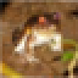

```python
import torch, torchvision, PIL
from torchvision.datasets import CIFAR10
from PIL import Image
import numpy as np
from io import BytesIO
import torchvision.transforms as transforms
import IPython.display
import lab_utils # Stuff from previous labs.
from lab_utils import pil2tensor, tensor2pil
%load_ext autoreload
%autoreload 2

classes = ['airplane', 'automobile', 'bird', 'cat', 'deer',
           'dog', 'frog', 'horse', 'ship', 'truck']
class2id = {name: idx for (idx, name) in enumerate(classes)}
trainset = CIFAR10(root='./data', train = True, download = True)

# Datasets need to implement the __len__ method.
print('\nThe training data has %d samples' % len(trainset))

# Datasets need to implement the __getitem__ method.
image_index = 0
img, label = trainset[image_index]
print('Image %d is a %s' % (image_index, classes[label]));
lab_utils.show_image(img.resize((128, 128)));  # Make bigger to visualize.
```

Let's show a group of images from the dataset to have a better idea of what the images look like.

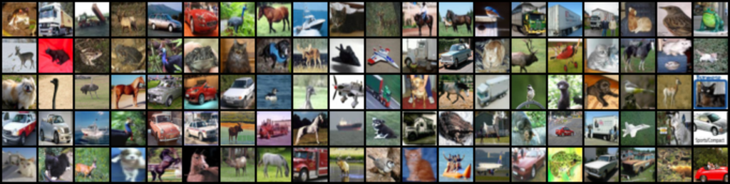

```python
sample_imgs = list()
for i in range(0, 100):
    img, _ = trainset[i]  # We don't do anything with the labels so we just use underscore _
    sample_imgs.append(img)

# Lots of hacks to show a list of PIL images as a grid of images.
def show_images(images, zoom = 1.0, ncols = 10):
    imgs = images if type(images[0]) == torch.Tensor else [pil2tensor(img) for img in images]
    grid = torchvision.utils.make_grid(imgs, nrow = ncols)
    pil_image = Image.fromarray(np.transpose(grid.mul(255).byte().numpy(), (1, 2, 0)))
    target_size = (int(zoom * pil_image.width), int(zoom * pil_image.height))
    pil_image = pil_image.resize(target_size, resample = PIL.Image.BILINEAR)
    bio = BytesIO(); pil_image.save(bio, format = 'png')
    IPython.display.display(IPython.display.Image(bio.getvalue()))

# Show images below at 2.0x zoom level. Remember they are 32x32 pixels only.
show_images(sample_imgs, zoom = 2.0, ncols = 20)
```

Let's make sure our train loaders transform the input image into a tensor.

```python
imgTransform = transforms.Compose([
    transforms.ToTensor()
])

trainset = CIFAR10(root='./data', train = True, transform = imgTransform)
valset = CIFAR10(root='./data', train = False, transform = imgTransform)
```

### 2. Computing a linear sofmax classifier "forward" pass.

The classifier will take as input vectors of size 3x32x32 = 3072, which is the size of the images. The classifier will output vector predictions of size 10, where each entry corresponds to a category. The function representing the linear classifier is:

$$\hat{y} = softmax(Wx+b)$$

where the $softmax$ function is applied to each element in the vector $a = Wx + b$. The weight matrix $W$ is of size 10x3072, and $b$ is a bias vector of size 10, so the output vector $a$ is of size 10 to match the number of categories that we want to predict. Both $W$ and $b$ need to be learned using the training data. The softmax function is defined for each entry $a_i$ in the vector $a$ as:

$$\hat{y}_i = softmax(a_i) = \frac{exp(a_i)}{\sum_{k=1}^{10}{exp(a_k)}}$$

The softmax function forces the entries in the vector $\hat{y}$ to sum to 1. We will discuss in the next section and during class in more detail why this transformation is convenient.

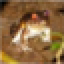

[output not shown]

```python
# Softmax function: exp(a) / sum(exp(a))
# Note that this function works for tensors of any shape, it is not a scalar function.
def softmax(a):
    max_val = a.max()  # This is to avoid variable overflows.
    exp_a = (a - max_val).exp()
    return exp_a.div(exp_a.sum())

# Classification function: y = softmax(Wx + b)
# Again, note this function is operating on vectors.
def linear(x, weight, bias):
    return torch.matmul(weight, x) + bias

# Initialize bias and weight with random values.
weight = torch.Tensor(10, 3 * 32 * 32).normal_(0, 0.01)
bias = torch.Tensor(10, 1).normal_(0, 0.01)

# Now predict the category using this un-trained classifier.
img, _ = trainset[0]
x = img.view(3 * 32 * 32, 1)
a = linear(x, weight, bias)
predictions = softmax(a)

# Show the results of the classifier.
lab_utils.show_image(tensor2pil(img).resize((128, 128)));
max_score, max_label = predictions.max(0)
print('Image predicted as %s with confidence %.2f' % (classes[max_label[0]], max_score[0]))
```

Now we have a working classifier but it is not a very good one. The rest of this lab will deal with "training" or "learning" the weight and bias parameters that minimize the number of errors of the classifier in the training data. Under certain conditions the parameters learned in the training data will also be generally good to make predictions on other data not seen during training. This property is called generalization. We will discuss in class more about those concepts.

### 3. Computing the loss function (also referred to as criterion in pytorch)

The first step to train our weight and bias parameters is to define a criterion for how wrong (or good) are the predictions given a weight and bias parameters. Loss functions measure the "distance" between a prediction $\hat{y}$ and a true label $y$. In the case of softmax, you can think of your true label $frog$ as a vector with all zeros except in the frog entry where it is one, e.g. $y = [0, 0, 0, 0, 0, 0, 1, 0, 0, 0]$. The loss function $\ell(y,\hat{y})$ between the prediction and true label is given then simply by the following equation: $$\ell(y, \hat{y})= -\sum_iy_ilog(\hat{y}_i)$$

Since the true label vector $y$ only has one non-zero entry, we know this sum really has only one term that is non-zero so you will usually see this loss function simply stated as:

$$\ell(label, \hat{y}) = -log(\hat{y}_{label})$$

The intuition behind this loss function is that we want the prediction score corresponding to the true label to be as high as possible (close to one), and by doing this we will also push the other scores to go close to zero because the softmax function forces these scores to sum to one. Since we want to pose the problem as a minimization problem, we use $-log(y_{label})$. (There are probabilistic and information theory interpretations of this loss but we will not analyze them for the purpose of this class)

```python
def loss(label, predictions):
    return -predictions[label].log()

# Let's compute predictions again.
predictions = softmax(linear(x, weight, bias))

for (i, pred) in enumerate(predictions.squeeze().tolist()):
    print('y_hat[%s] = %.2f' % (classes[i], pred))

# The correct label for this image is 'frog'.
loss_value = loss(class2id['frog'], predictions)
print('\nLoss: %.2f' % loss_value[0])
```

```
y_hat[airplane] = 0.11
y_hat[automobile] = 0.11
y_hat[bird] = 0.09
y_hat[cat] = 0.08
y_hat[deer] = 0.08
y_hat[dog] = 0.07
y_hat[frog] = 0.12
y_hat[horse] = 0.13
y_hat[ship] = 0.08
y_hat[truck] = 0.12

Loss: 2.09
```

### 4. Computing Numerical Gradients for parameters $W$ and $b$

The rest of this lab will be about modifying the parameters $W$ and $b$ so that the loss for all the images in the training set is as small as possible. Randomly modifying the values of these parameters until finding a set of values for which the loss becomes smaller might work reasonably well when few parameters need to be estimated but our weight matrix $W$ alone has 3072x10 = 30720 parameters, and some models that we will study later in the class have billions of parameters.

We will instead use Stochastic Gradient Descent (SGD), which is an optimization technique that consists on computing the loss for a training sample or a small group of training samples and modifying the parameters $W$ and $b$ by shifting them a small amount in the direction of their gradients, we will go over this in more detail later. We will first focus on how to compute those gradients, particularly $\frac{\partial \ell}{\partial w_{ij}}$ and $\frac{\partial \ell}{\partial b_i}$.

A simple yet effective first approach is to compute the gradients with a numerical approximation using the definition of derivatives: $$f'(x) = lim_{h\rightarrow0}\frac{f(x + h) - f(x - h)}{2h}$$. For a given single input pair $(x, y)$ the output of the loss function $\ell$ just depends on the parameters $W$ and $b$. Taken this into account, for each entry $w_{ij}$ in the weight matrix $W$ we are interested in the following:

$$\frac{\partial \ell(W,b)}{\partial w_{ij}} = \frac{\ell(W + \mathcal{E}_{ij},b) - \ell(W - \mathcal{E}_{ij}, b)}{2\epsilon}, $$

where $\mathcal{E}_{ij}$ is a matrix that has $\epsilon$ in its $(i,j)$ entry and zeroes everywhere else. Intuitively this gradient tells us how would the value of the loss changes if we shake a particular weight $w_{ij}$ by an $\epsilon$ amount. We can do the same to compute derivatives with respect to the bias parameters $b_i$. Next we write code to compute gradients for our frog image using this approach:

```python
epsilon = 0.0001
shifted_weight = weight.clone()  # Make a copy of the weights.

# Initialize gradients for bias and weight with zero values.
gradWeight = torch.Tensor(10, 3 * 32 * 32).fill_(0)
gradBias = torch.Tensor(10, 1).fill_(0)

# Compute gradients for each weight w_ij
for i in range(0, weight.shape[0]):
    for j in range(0, weight.shape[1]):
        # Compute f(x + h)
        shifted_weight[i, j] = shifted_weight[i, j] + epsilon
        f1 = softmax(linear(x, shifted_weight, bias))
        loss1 = loss(class2id['frog'], f1)
        shifted_weight[i, j] = weight[i, j] # restore original value.

        # Compute f(x - h)
        shifted_weight[i, j] = shifted_weight[i, j] - epsilon
        f2 = softmax(linear(x, shifted_weight, bias))
        loss2 = loss(class2id['frog'], f2)
        shifted_weight[i, j] = weight[i, j] # restore original value.

        # Compute [f(x + h) - f(x - h)] / 2h.
        gradWeight[i, j] = (loss1[0] - loss2[0]) / (2 * epsilon)

numericalGradWeight = gradWeight # Let's save this variable with another name.
print(numericalGradWeight)
```

```
 0.0256  0.0191  0.0221  ...   0.0614  0.0364  0.0316
 0.0250  0.0173  0.0209  ...   0.0584  0.0358  0.0298
 0.0197  0.0137  0.0167  ...   0.0471  0.0280  0.0244
          ...             ⋱             ...
 0.0256  0.0191  0.0226  ...   0.0614  0.0370  0.0316
 0.0173  0.0131  0.0149  ...   0.0423  0.0256  0.0221
 0.0250  0.0185  0.0221  ...   0.0596  0.0364  0.0304
[torch.FloatTensor of size 10x3072]
```

### 5. Computing Analytic Gradients for parameters $W$ and $b$

Unfortunately computing numerical gradients requires evaluating the function f as many times as the number of parameters in the model which could be a very large number. In practice, gradients are computed analytically instead of numerically. This means we will be computing the derivatives $\partial \ell/\partial w_{ij}$ and $\partial \ell/\partial b_{i}$ by first deriving their analytic equation using our knowledge of basic calculus. Typically we do not compute the derivatives with respect to the parameters directly but the derivatives with respect to inputs or outputs, and use those to compute the derivatives with respect to the parameters using the chain rule. First let's write here again our loss function $\ell$ for a single training example $(x, label)$:

\begin{equation} \ell(W, b) = -\text{log}(\hat{y}_{label}(W, b)) = -\text{log}\Big(\frac{\text{exp}(a_{label}(W, b))}{\sum_{k=1}^{10}{\text{exp}(a_k(W,b))}}\Big) \end{equation}

For simplicity we will drop the parameters $W$ and $b$ from the notation but it is important to remember what variables depend on them.

\begin{equation} \ell = -\text{log}\Big(\frac{\text{exp}(a_{label})}{\sum_{k=1}^{10}{\text{exp}(a_k)}}\Big) \end{equation}

We will compute the derivatives with respect to parameters $w_{ij}$ and $b_i$ using the chain rule as:

\begin{equation} \frac{\partial \ell}{\partial w_{ij}} = \frac{\partial \ell}{\partial a_{i}}\frac{\partial a_i}{\partial w_{ij}} \quad\text{and}\quad \frac{\partial \ell}{\partial b_{i}} = \frac{\partial \ell}{\partial a_{i}}\frac{\partial a_i}{\partial b_{i}} \end{equation}

These derivatives correspond to the following expressions (you can trust this for now, but an appendix with careful derivations is included at the end, or even better you can try deriving it yourself on paper):

\begin{equation} \frac{\partial \ell}{\partial a_{i}} = \frac{\partial}{\partial a_{i}}\Big[-\text{log}\Big(\frac{\text{exp}(a_{label})}{\sum_{k=1}^{10}{\text{exp}(a_k)}}\Big)\Big] = \hat{y}_{i} - y_i \tag{See Appendix, or derive it yourself} \end{equation}\begin{equation} \frac{\partial a_i}{\partial w_{ij}} = \frac{\partial}{\partial w_{ij}} (w_{i,1}x_1 + ... + w_{ij}x_j + ... + w_{i, 3072}x_{3072} + b_i) = x_j \end{equation}\begin{equation} \frac{\partial a_i}{\partial b_{i}} = \frac{\partial}{\partial b_{i}} (w_{i,1}x_1 + ... + w_{ij}x_j + ... + w_{i, 3072}x_{3072} + b_i) = 1 \end{equation}

Next we will compute the gradients with respect to parameters using the formulas above for our frog image and compare them with the ones obtained using our numerical gradients:

```python
def loss_softmax_backward(label, predictions):
    grad_inputs = predictions.clone() #case i != label
    grad_inputs[label] = grad_inputs[label] - 1 #case i = label
    return grad_inputs

def linear_backward(x, weight, bias, gradOutput):
    gradBias = bias.clone().zero_()
    gradWeight = weight.clone().zero_()
    gradWeight = gradOutput * x.t()
    gradBias.copy_(gradOutput)
    return gradWeight, gradBias

gradOutput = loss_softmax_backward(class2id['frog'], predictions)
gradWeight, gradBias = linear_backward(x, weight, bias, gradOutput)

# Let's print the gradWeight again.
print(gradWeight)

g1 = gradWeight.view(-1, 1).squeeze()
g2 = numericalGradWeight.view(-1, 1).squeeze()
print('Distance betwen numerical and analytical gradients: %.6f' %
      (torch.norm(g1 - g2) / torch.norm(g1 + g2)))
```

```
 0.0258  0.0188  0.0218  ...   0.0611  0.0367  0.0314
 0.0246  0.0179  0.0208  ...   0.0584  0.0350  0.0300
 0.0199  0.0145  0.0168  ...   0.0471  0.0283  0.0242
          ...             ⋱             ...
 0.0259  0.0189  0.0220  ...   0.0616  0.0369  0.0317
 0.0178  0.0130  0.0151  ...   0.0423  0.0254  0.0217
 0.0251  0.0183  0.0213  ...   0.0596  0.0358  0.0306
[torch.FloatTensor of size 10x3072]

Distance betwen numerical and analytical gradients: 0.001416
```

### 6. Stochastic Gradient Descent (SGD)

Now that we compute gradients efficiently we will implement the stochastic gradient descent loop that moves the weights according to the gradients. In each iteration we sample an (input, label) pair and compute the gradients of the parameters, then we update the parameters according to the following rules:

$$w_{ij} = w_{ij} - \lambda\frac{\partial \ell}{\partial w_{ij}}$$$$b_i = b_i - \lambda\frac{\partial \ell}{\partial b_i}$$

where $\lambda$ is the learning rate. This value is set empirically and is usually modified during training. We will provide additional practical advice on choosing the learning rate as well as other tricks during class and in office hours but there is no single general advice for this. Please do not ask your instructors or TAs what value to use for a learning rate, or other hyperparameters for labs or your project. These are generally empirically determined. Maybe over time with experience you will develop the ability to choose them appropriately on your first try. This is the reason people with these skils are in high demand.

```python
# Define a learning rate. This is what I found worked but did not try exahustively.
learningRates = [1e-4, 1e-5]
weightDecay = 1e-6 # Regularization strength.

# Initialize bias and weight with random values again.
weight = torch.Tensor(10, 3 * 32 * 32).normal_(0, 0.01)
bias = torch.Tensor(10, 1).zero_()

# Training loop. Please make sure you understand every single line of code below.
# Go back to some of the previous steps in this lab if necessary.
for epoch in range(0, 10):
    correct = 0.0
    cum_loss = 0.0
    learningRate = learningRates[0] if epoch < 5 else learningRates[1]

    # Make a pass over the training data.
    for (i, (img, label)) in enumerate(trainset):
        x = img.view(3 * 32 * 32, 1)

        # Forward pass. (Prediction stage)
        predictions = softmax(linear(x, weight, bias))
        cum_loss += loss(label, predictions)[0]
        max_score, max_label = predictions.max(0)
        if max_label[0] == label: correct += 1

        #Backward pass. (Gradient computation stage)
        gradOutput = loss_softmax_backward(label, predictions)
        gradWeight, gradBias = linear_backward(x, weight, bias, gradOutput)

        # Parameter updates.
        gradWeight.add_(weightDecay, weight)
        weight.add_(-learningRate, gradWeight)
        bias = bias - learningRate * gradBias

        # Logging the current results on training.
        if (i + 1) % 10000 == 0:
            print('Train-epoch %d. Iteration %05d, Avg-Loss: %.4f, Accuracy: %.4f' %
                  (epoch, i + 1, cum_loss / (i + 1), correct / (i + 1)))


    # Make a pass over the validation data.
    correct = 0.0
    cum_loss = 0.0
    for (i, (img, label)) in enumerate(valset):
        x = img.view(3 * 32 * 32, 1)

        # Forward pass. (Prediction stage)
        predictions = softmax(linear(x, weight, bias))
        cum_loss += loss(label, predictions)[0]
        max_score, max_label = predictions.max(0)
        if max_label[0] == label: correct += 1

    # Logging the current results on validation.
    print('Validation-epoch %d. Avg-Loss: %.4f, Accuracy: %.4f' %
          (epoch, cum_loss / len(valset), correct / len(valset)))
```

```
Train-epoch 0. Iteration 10000, Avg-Loss: 2.1189, Accuracy: 0.2376
Train-epoch 0. Iteration 20000, Avg-Loss: 2.0569, Accuracy: 0.2668
Train-epoch 0. Iteration 30000, Avg-Loss: 2.0113, Accuracy: 0.2898
Train-epoch 0. Iteration 40000, Avg-Loss: 1.9857, Accuracy: 0.3020
Train-epoch 0. Iteration 50000, Avg-Loss: 1.9671, Accuracy: 0.3097
Validation-epoch 0. Avg-Loss: 1.8712, Accuracy: 0.3465
Train-epoch 1. Iteration 10000, Avg-Loss: 1.8554, Accuracy: 0.3540
Train-epoch 1. Iteration 20000, Avg-Loss: 1.8613, Accuracy: 0.3528
Train-epoch 1. Iteration 30000, Avg-Loss: 1.8494, Accuracy: 0.3583
Train-epoch 1. Iteration 40000, Avg-Loss: 1.8473, Accuracy: 0.3599
Train-epoch 1. Iteration 50000, Avg-Loss: 1.8462, Accuracy: 0.3597
Validation-epoch 1. Avg-Loss: 1.8238, Accuracy: 0.3673
Train-epoch 2. Iteration 10000, Avg-Loss: 1.8085, Accuracy: 0.3715
Train-epoch 2. Iteration 20000, Avg-Loss: 1.8199, Accuracy: 0.3680
Train-epoch 2. Iteration 30000, Avg-Loss: 1.8105, Accuracy: 0.3724
Train-epoch 2. Iteration 40000, Avg-Loss: 1.8108, Accuracy: 0.3736
Train-epoch 2. Iteration 50000, Avg-Loss: 1.8121, Accuracy: 0.3730
Validation-epoch 2. Avg-Loss: 1.8011, Accuracy: 0.3723
Train-epoch 3. Iteration 10000, Avg-Loss: 1.7839, Accuracy: 0.3828
Train-epoch 3. Iteration 20000, Avg-Loss: 1.7975, Accuracy: 0.3771
Train-epoch 3. Iteration 30000, Avg-Loss: 1.7889, Accuracy: 0.3810
Train-epoch 3. Iteration 40000, Avg-Loss: 1.7899, Accuracy: 0.3817
Train-epoch 3. Iteration 50000, Avg-Loss: 1.7922, Accuracy: 0.3808
Validation-epoch 3. Avg-Loss: 1.7869, Accuracy: 0.3778
Train-epoch 4. Iteration 10000, Avg-Loss: 1.7676, Accuracy: 0.3893
Train-epoch 4. Iteration 20000, Avg-Loss: 1.7823, Accuracy: 0.3842
Train-epoch 4. Iteration 30000, Avg-Loss: 1.7741, Accuracy: 0.3878
Train-epoch 4. Iteration 40000, Avg-Loss: 1.7755, Accuracy: 0.3886
Train-epoch 4. Iteration 50000, Avg-Loss: 1.7782, Accuracy: 0.3875
Validation-epoch 4. Avg-Loss: 1.7768, Accuracy: 0.3818
Train-epoch 5. Iteration 10000, Avg-Loss: 1.7430, Accuracy: 0.4050
Train-epoch 5. Iteration 20000, Avg-Loss: 1.7587, Accuracy: 0.4000
Train-epoch 5. Iteration 30000, Avg-Loss: 1.7512, Accuracy: 0.4018
Train-epoch 5. Iteration 40000, Avg-Loss: 1.7531, Accuracy: 0.4026
Train-epoch 5. Iteration 50000, Avg-Loss: 1.7560, Accuracy: 0.4007
Validation-epoch 5. Avg-Loss: 1.7667, Accuracy: 0.3887
Train-epoch 6. Iteration 10000, Avg-Loss: 1.7409, Accuracy: 0.4046
Train-epoch 6. Iteration 20000, Avg-Loss: 1.7570, Accuracy: 0.4002
Train-epoch 6. Iteration 30000, Avg-Loss: 1.7497, Accuracy: 0.4022
Train-epoch 6. Iteration 40000, Avg-Loss: 1.7516, Accuracy: 0.4028
Train-epoch 6. Iteration 50000, Avg-Loss: 1.7547, Accuracy: 0.4010
Validation-epoch 6. Avg-Loss: 1.7658, Accuracy: 0.3889
Train-epoch 7. Iteration 10000, Avg-Loss: 1.7397, Accuracy: 0.4050
Train-epoch 7. Iteration 20000, Avg-Loss: 1.7558, Accuracy: 0.4004
Train-epoch 7. Iteration 30000, Avg-Loss: 1.7485, Accuracy: 0.4026
Train-epoch 7. Iteration 40000, Avg-Loss: 1.7505, Accuracy: 0.4032
Train-epoch 7. Iteration 50000, Avg-Loss: 1.7536, Accuracy: 0.4012
Validation-epoch 7. Avg-Loss: 1.7649, Accuracy: 0.3890
Train-epoch 8. Iteration 10000, Avg-Loss: 1.7385, Accuracy: 0.4047
Train-epoch 8. Iteration 20000, Avg-Loss: 1.7547, Accuracy: 0.4007
Train-epoch 8. Iteration 30000, Avg-Loss: 1.7474, Accuracy: 0.4028
Train-epoch 8. Iteration 40000, Avg-Loss: 1.7494, Accuracy: 0.4033
Train-epoch 8. Iteration 50000, Avg-Loss: 1.7526, Accuracy: 0.4016
Validation-epoch 8. Avg-Loss: 1.7641, Accuracy: 0.3892
Train-epoch 9. Iteration 10000, Avg-Loss: 1.7374, Accuracy: 0.4054
Train-epoch 9. Iteration 20000, Avg-Loss: 1.7537, Accuracy: 0.4010
Train-epoch 9. Iteration 30000, Avg-Loss: 1.7463, Accuracy: 0.4031
Train-epoch 9. Iteration 40000, Avg-Loss: 1.7484, Accuracy: 0.4036
Train-epoch 9. Iteration 50000, Avg-Loss: 1.7516, Accuracy: 0.4019
Validation-epoch 9. Avg-Loss: 1.7633, Accuracy: 0.3897
```

### Observations:

If you run the code from the previous section, you will now have a model that can make predictions that are much better than random chance (chance is 10% since we have 10 categories) but that is still far from perfect (100% accuracy). You can see how good are the best models on this task and dataset [here](http://rodrigob.github.io/are_we_there_yet/build/classification_datasets_results.html#43494641522d3130). Over the course of this class you will learn how to train more robust models that can achieve much higher accuracy but a lot of the principles learned in this lecture will apply to more complex models as well. More complex model will have a lot more complex functions than just a linear classifier, and the SGD optimization also can have several improvements. Just for fun let's run an image through our trained model by copy-pasting some code we wrote earlier.

[figure not shown]

[output not shown]

```python
# Now predict the category using this trained classifier!.
img, _ = trainset[5]
x = img.view(3 * 32 * 32, 1)
a = linear(x, weight, bias)
predictions = softmax(a)

# Show the results of the classifier.
lab_utils.show_image(tensor2pil(img).resize((128, 128)));
max_score, max_label = predictions.max(0)
print('Image predicted as %s with confidence %.2f' % (classes[max_label[0]], max_score[0]))

# Print out detailed predictions.
for (i, pred) in enumerate(predictions.squeeze().tolist()):
    print('y_hat[%s] = %.2f' % (classes[i], pred))
```

Finally we are visualizing below the weights learned by the linear classifier as images.

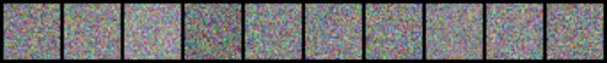

```
['airplane', 'automobile', 'bird', 'cat', 'deer', 'dog', 'frog', 'horse', 'ship', 'truck']
```

```python
w_imgs = list()
for i in range(0, 10):
    w_img = weight[i].view(3, 32, 32).clone().contiguous()
    w_img = (w_img - w_img.min()) / (w_img.max() - w_img.min())
    w_imgs.append(w_img)

show_images(w_imgs, zoom = 2.0)
print(classes)
```

## Lab Questions (5pts)

1. What is the accuracy that you obtained by running the code in Section 6 after all epochs? Plot here two figures. One showing the loss both in training and validation after every epoch (use legends for training and validation, x-axis are the epoch numbers, y-axis shows loss scores), and another showing the accuracy in training and validation after every epoch (same as before x-axis are epochs, and y-axis are accuracy scores). Comment on the results (1pts).
2. Derive the analytic gradient for the softmax function (this will be similar to the derivation shown in the Appendix for the negative LogSoftMax). Show your derivation here using LaTeX as in the Appendix (might be easier) or attach an additional image scan if you do it on paper. I will appreciate if you show your derivation here. Note this derivation is similar as the appendix but here we don't have the log and the negative sign (2pts):
   $$ \frac{\partial}{\partial a_{i}}\Big[\Big(\frac{\text{exp}(a_{label})}{\sum_{k=1}^{10}{\text{exp}(a_k)}}\Big)\Big] $$
3. After you derive the above analytic gradient, provide implementations for the following (1pts). Note that in this question I'm not asking you to train the network using your loss_backward and softmax_backward implementations but you might want to do it if you want to check if your solution works.
4. In the previous lecture you learned how to compute the color histogram of an image. Try training the linear softmax classifier in this lab using input color histograms instead of the flattened input images used in this lecture. Modify the code to accomplish this and report here your plots for training and validation accuracy, and loss as in question 1. This requires changing the weight matrix as well as incorporating histogram computation. You are free to define number of bins and other appropriate settings you consider. (1pts).

#### Optional

1. Train the model using a max-margin loss of the form: $$\ell(\hat{y}, label) = \sum_{j \neq label} \text{max}(0, y_j - y_{label} + \Delta)$$ This will require implementing the forward and backward pass for this loss, as well as choosing an appropriate margin value $\Delta$. Print the training and validation plots for this experiment (as in the main lab question 1). Also visualize the learned weights under this loss as we did in the last section of the lab. You can read more about intutions on max-margin losses from Stanford's CS231n lecture notes [here](http://cs231n.github.io/linear-classify/) (2pts)
2. During class we discussed the GIST and HoG feature descriptors. Instead of using the image pixels directly, try to train the softmax linear classifier in this lab using one of those features. Feel free to use public implementations of HoG such as this one http://scikit-image.org/docs/dev/auto_examples/features_detection/plot_hog.html (1pts).

### Question 1: Training and Validation Analysis

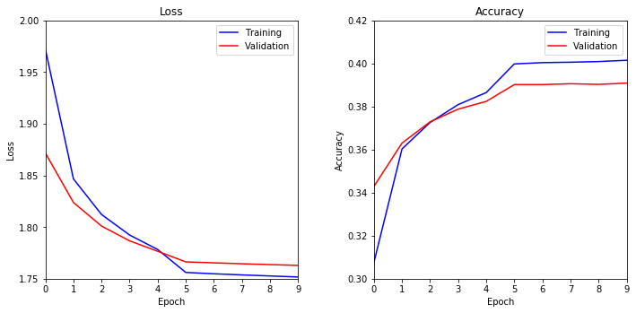

```python
import matplotlib.pyplot as plt
plt.subplot(121)
plt.plot([0,1,2,3,4,5,6,7,8,9],[1.9722,1.8466,1.8122,1.7923,1.7783,1.7561,1.7548,1.7537,1.7527,1.7517],'b-',label='Training')
plt.subplot(121)
plt.plot([0,1,2,3,4,5,6,7,8,9],[1.8717,1.8238,1.8010,1.7867,1.7766,1.7663,1.7654,1.7645,1.7637,1.7629],'r-',label='Validation')
plt.ylabel('Loss')
plt.xlabel('Epoch')
plt.title('Loss')
plt.axis([0,9,1.75,2])
plt.legend()

plt.subplot(122)
plt.plot([0,1,2,3,4,5,6,7,8,9],[0.3076,.3603,.3726,.3809,.3865,.3998,.4004,.4006,.4009,.4015],'b-',label='Training')
plt.subplot(122)
plt.plot([0,1,2,3,4,5,6,7,8,9],[.3429,.3630,.3729,.3788,.3824,.3902,.3902,.3906,.3903,.3909],'r-',label='Validation')
plt.ylabel('Accuracy')
plt.xlabel('Epoch')
plt.title('Accuracy')
plt.axis([0,9,0.3,0.42])
plt.subplots_adjust(top=1, bottom=0, left=0, right=1.5, hspace=0.35, wspace=0.3)
plt.legend()
plt.show()
```

*Note that the axes have been set to emphasize convergence.*

### Question 2: Derivation

$$ \frac{\partial}{\partial a_{i}}\Big[\Big(\frac{\text{exp}(a_{label})}{\sum_{k=1}^{10}{\text{exp}(a_k)}}\Big)\Big] = ? $$

Case $i = label$:

$$\frac{\partial s}{\partial a_{label}} = \frac{ \Big(\frac{\partial}{\partial a_{label}} \text{exp}(a_{label})\Big) \Big(\sum_{k=1}^{10}{\text{exp}(a_k)}\Big) - \Big( \text{exp}(a_{label}) \Big) \Big( \frac{\partial}{\partial a_{label}} \sum_{k=1}^{10}{\text{exp}(a_k)}\Big) }{ \Big(\sum_{k=1}^{10}{\text{exp}(a_k)}\Big)^2}$$$$\frac{\partial s}{\partial a_{label}} = \frac{ \Big(\text{exp}(a_{label})\Big) \Big(\sum_{k=1}^{10}{\text{exp}(a_k)}\Big) - \Big( \text{exp}(a_{label}) \Big) \Big(\text{exp}(a_{label})\Big) }{ \Big(\sum_{k=1}^{10}{\text{exp}(a_k)}\Big)^2}$$$$\frac{\partial s}{\partial a_{label}} = \frac{\text{exp}(a_{label})}{\sum_{k=1}^{10}{\text{exp}(a_k)}} - \Big( \frac{\text{exp}(a_{label})}{\sum_{k=1}^{10}{\text{exp}(a_k)}}\Big)^2$$$$\frac{\partial s}{\partial a_{label}}= \hat{y}_{label} - \hat{y}^2_{label}$$

Case $i \neq label$:

$$\frac{\partial s}{\partial a_{i}} = \frac{ \Big(\frac{\partial}{\partial a_{i}} \text{exp}(a_{label})\Big) \Big(\sum_{k=1}^{10}{\text{exp}(a_k)}\Big) - \Big( \text{exp}(a_{label}) \Big) \Big( \frac{\partial}{\partial a_{i}} \sum_{k=1}^{10}{\text{exp}(a_k)}\Big) }{ \Big(\sum_{k=1}^{10}{\text{exp}(a_k)}\Big)^2}$$$$\frac{\partial s}{\partial a_{i}} = \frac{ \Big(0\Big) \Big(\sum_{k=1}^{10}{\text{exp}(a_k)}\Big) - \Big( \text{exp}(a_{label}) \Big) \Big(\text{exp}(a_{i})\Big) }{ \Big(\sum_{k=1}^{10}{\text{exp}(a_k)}\Big)^2}$$$$\frac{\partial s}{\partial a_{i}} = -\frac{ \Big(\text{exp}(a_{label})\Big)\Big(\text{exp}(a_{i})\Big) }{ \Big( \sum_{k=1}^{10}{\text{exp}(a_k)}\Big)^2} = -\Big( \frac{\text{exp}(a_{label})}{\sum_{k=1}^{10}{\text{exp}(a_k)}} \Big)\Big( \frac{\text{exp}(a_{i})}{\sum_{k=1}^{10}{\text{exp}(a_k)}}\Big)$$$$\frac{\partial s}{\partial a_{i}} = -\hat{y}_{label}\hat{y}_{i}$$

Given $i=label$ we can rewrite the following so that its structure resembles $i \neq label$:

$$\frac{\partial s}{\partial a_{i}} = -\hat{y}_{label}\hat{y}_{i} + \hat{y}_{label}$$

We can now put both derivatives together using Iverson bracket notation:

$$\frac{\partial s}{\partial a_{i}} = -\hat{y}_{label}\hat{y}_{i} + \hat{y}_{label}[i=label]$$

### Question 3: Implementation

##### This implementation provides the same accuracy as the loss_softmax_backward() function in part 6 (tested)

Note that without access to $y_{label}$ in softmax*backward(), we must make some adjustments to $\frac{\partial \ell}{\partial s}$ so that $\frac{\partial \ell}{\partial a} = \frac{\partial \ell}{\partial s}\frac{\partial s}{\partial a} = \hat{y}*{i} - 1[i=label]$, which is the desired outcome.

$$\frac{\partial \ell}{\partial s} = \frac{\hat{y}_{i} - 1[i=label]}{-y_{i}^2}$$$$\frac{\partial \ell}{\partial a} = \frac{\partial \ell}{\partial s}\frac{\partial s}{\partial a} = \Big(\frac{\hat{y}_{i} - 1[i=label]}{-y_{i}^2}\Big) \Big( -\hat{y}_{i}^2\Big) = \hat{y}_{i} - 1[i=label]$$

Note that when $i \neq label$, $\frac{\partial \ell}{\partial s}$ evaluates to $-\frac{1}{\hat{y}_{i}}$, which we can confirm is correct:

$$\frac{\partial}{\partial s} \Big( -\log{(\text{softmax})} \Big) = -\frac{1}{\text{softmax}} = -\frac{1}{\hat{y}_{i}}$$

```python
def loss_backward(label, predictions):
    # return gradient of loss with respect to softmax()
    grad_inputs = predictions.clone().zero_()
    grad_inputs = torch.div(grad_inputs.clone().fill_(-1), predictions) # compute dl/ds, where s = softmax
    temp1 = torch.mul(predictions,predictions)                          # y_i * y_label
    temp2 = torch.div(grad_inputs.clone().fill_(1), temp1[label])       # 1/(y_i * y_label)
    grad_inputs[label] = grad_inputs[label] + temp2[label]              # adjust ground truth gradient
    return grad_inputs # dl/ds

def softmax_backward(inputTensor, gradOutput):
    # return gradient of loss with respect to activations
    grad_inputs = inputTensor.clone().zero_()
    y = softmax(inputTensor)                         # compute softmax
    inputTensor = torch.mul(-y,y)                    # compute ds/da, partial of softmax w.r.t. activations (general case)
    grad_inputs = torch.mul(inputTensor, gradOutput) # dl/da = dl/ds * ds/da
    return grad_inputs # dl/da


# EXAMPLE PLACEMENT OF FUNCTIONS
grads_t = loss_backward(label, predictions)
grads = softmax_backward(a, grads_t) # a = linear(x, weight, bias)
gradWeight, gradBias = linear_backward(x, weight, bias, grads)
```

### Question 4: Histograms

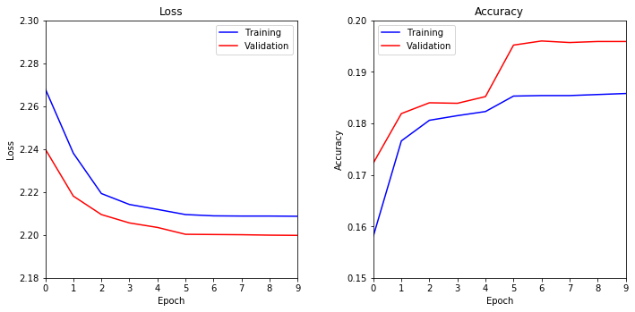

```python
import matplotlib.pyplot as plt
plt.subplot(121)
plt.plot([0,1,2,3,4,5,6,7,8,9],[2.2681,2.2381,2.2193,2.2142,2.2119,2.2095,2.2089,2.2088,2.2088,2.2087],'b-',label='Training')
plt.subplot(121)
plt.plot([0,1,2,3,4,5,6,7,8,9],[2.24,2.2181,2.2095,2.2056,2.2035,2.2003,2.2002,2.2001,2.1999,2.1998],'r-',label='Validation')
plt.ylabel('Loss')
plt.xlabel('Epoch')
plt.title('Loss')
plt.axis([0,9,2.18,2.3])
plt.legend()

plt.subplot(122)
plt.plot([0,1,2,3,4,5,6,7,8,9],[0.1581,.1766,.1806,.1815,.1823,.1853,.1854,.1854,.1856,.1858],'b-',label='Training')
plt.subplot(122)
plt.plot([0,1,2,3,4,5,6,7,8,9],[0.1723,.1819,.1840,.1839,.1852,.1952,.1960,.1957,.1959,.1959],'r-',label='Validation')
plt.ylabel('Accuracy')
plt.xlabel('Epoch')
plt.title('Accuracy')
plt.axis([0,9,0.15,0.2])
plt.subplots_adjust(top=1, bottom=0, left=0, right=1.5, hspace=0.35, wspace=0.3)
plt.legend()
plt.show()
```

*Note that the axes have been set to emphasize convergence.*

As we can see, loss and accuracy decrease and increase, respectively, with successive epochs. Intuitively, this makes sense$-$our learning algorithm is continually updating the weight and bias vectors based on the backpropagation of error in order to minimize loss (and thus improve accuracy). This inverse relationship is evident in the inverse nature of the graphs above. We also observe a convergence at epoch 5 when the learning rate slows.

The large discrepancy between the accuracy of training the linear softmax classifier on the histogram versus the actual images is most likely due to the loss of location information. In the case of the histogram, we are only able to train on tonal frequency; thus, two different classes of images with similar tonal frequencies (horse and dog, or ship and airplane) will be difficult to discern. While tonal frequency is still useful in distinguishing frogs from airplanes (hence why we are able to achieve double the odds of pure chance) it lacks the location information necessary for better accuracy.

```python
# CODE for question 4
# Histogram parameters
numbins = 12
hist_max = 1.0

# Define a learning rate. This is what I found worked but did not try exahustively.
learningRates = [8e-3, 7e-4]
weightDecay = 1e-6 # Regularization strength.

# Initialize bias and weight with random values again.
weight = torch.Tensor(10, numbins).normal_(0, 0.01)
bias = torch.Tensor(10, 1).zero_()

# Training loop. Please make sure you understand every single line of code below.
# Go back to some of the previous steps in this lab if necessary.
for epoch in range(0, 15):
    correct = 0.0
    cum_loss = 0.0
    learningRate = learningRates[0] if epoch < 5 else learningRates[1]

    # Make a pass over the training data.
    for (i, (img, label)) in enumerate(trainset):
        # Histogram Computations
        hist = torch.histc(img, bins = numbins, min = 0.0, max = hist_max)
        hist = hist.div(hist.sum())

        x = hist.view(numbins, 1)

        # Forward pass. (Prediction stage)
        a = linear(x, weight, bias)
        predictions = softmax(a)
        cum_loss += loss(label, predictions)[0]
        max_score, max_label = predictions.max(0)
        if max_label[0] == label: correct += 1

        #Backward pass. (Gradient computation stage)
        grads_t = loss_backward(label, predictions)
        gradOutput = softmax_backward(a, grads_t)
        gradWeight, gradBias = linear_backward(x, weight, bias, gradOutput)

        # Parameter updates.
        gradWeight.add_(weightDecay, weight)
        weight.add_(-learningRate, gradWeight)
        bias = bias - learningRate * gradBias

        # Logging the current results on training.
        if (i + 1) % 10000 == 0:
            print('Train-epoch %d. Iteration %05d, Avg-Loss: %.4f, Accuracy: %.4f' %
                  (epoch, i + 1, cum_loss / (i + 1), correct / (i + 1)))


    # Make a pass over the validation data.
    correct = 0.0
    cum_loss = 0.0
    for (i, (img, label)) in enumerate(valset):
        # Histogram Computations
        hist = torch.histc(img, bins = numbins, min = 0.0, max = hist_max)
        hist = hist.div(hist.sum())

        x = hist.view(numbins, 1)

        # Forward pass. (Prediction stage)
        predictions = softmax(linear(x, weight, bias))
        cum_loss += loss(label, predictions)[0]
        max_score, max_label = predictions.max(0)
        if max_label[0] == label: correct += 1

    # Logging the current results on validation.
    print('Validation-epoch %d. Avg-Loss: %.4f, Accuracy: %.4f' %
          (epoch, cum_loss / len(valset), correct / len(valset)))
```

### Optional 1: min-max loss

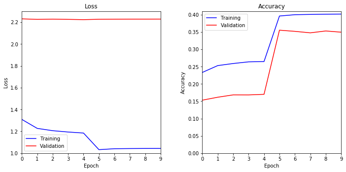

```python
import matplotlib.pyplot as plt
plt.subplot(121)
plt.plot([0,1,2,3,4,5,6,7,8,9],[1.3095,1.2271,1.2060,1.1938,1.1844,1.0322,1.0407,1.0423,1.0432,1.0435],'b-',label='Training')
plt.subplot(121)
plt.plot([0,1,2,3,4,5,6,7,8,9],[2.2302,2.2257,2.2276,2.2256,2.2230,2.2265,2.2272,2.2278,2.2279,2.2282],'r-',label='Validation')
plt.ylabel('Loss')
plt.xlabel('Epoch')
plt.title('Loss')
plt.axis([0,9,1,2.3])
plt.legend()

plt.subplot(122)
plt.plot([0,1,2,3,4,5,6,7,8,9],[0.2332,.2530,.2590,.2638,.2647,.3962,.4000,.4008,.4015,.4018],'b-',label='Training')
plt.subplot(122)
plt.plot([0,1,2,3,4,5,6,7,8,9],[0.1531,.1616,.1684,.1683,.1700,.3553,.3519,.3476,.3530,.3495],'r-',label='Validation')
plt.ylabel('Accuracy')
plt.xlabel('Epoch')
plt.title('Accuracy')
plt.axis([0,9,0,0.41])
plt.subplots_adjust(top=1, bottom=0, left=0, right=1.5, hspace=0.35, wspace=0.3)
plt.legend()
plt.show()
```

```python
delta = 0.2

def loss_svm(label, predictions, delta):
    margins = torch.max(torch.zeros(len(predictions)),predictions-predictions[label]+delta).select(1,1)
    margins[label] = 0
    return torch.sum(margins)

def loss_svm_backward(label, predictions, delta):
    # margins
    margins = torch.max(torch.zeros(len(predictions)),predictions-predictions[label]+delta).select(1,1)
    grads = margins.gt(0)
    grads = grads.type(torch.FloatTensor)
    # correct class
    margins[label] = 0
    grads[label] = -torch.sum(margins)
    grads = grads.unsqueeze(1)
    #print(grads)
    return grads

# Define a learning rate. This is what I found worked but did not try exahustively.
learningRates = [1e-4, 1e-5]
weightDecay = 1e-6 # Regularization strength.

# Initialize bias and weight with random values again.
weight = torch.Tensor(10, 3 * 32 * 32).normal_(0, 0.01)
bias = torch.Tensor(10, 1).zero_()

# Training loop. Please make sure you understand every single line of code below.
# Go back to some of the previous steps in this lab if necessary.
for epoch in range(0, 10):
    correct = 0.0
    cum_loss = 0.0
    learningRate = learningRates[0] if epoch < 5 else learningRates[1]

    # Make a pass over the training data.
    for (i, (img, label)) in enumerate(trainset):
        x = img.view(3 * 32 * 32, 1)

        # Forward pass. (Prediction stage)
        predictions = linear(x, weight, bias)
        cum_loss += loss_svm(label, predictions, delta)
        max_score, max_label = predictions.max(0)
        if max_label[0] == label: correct += 1

        #Backward pass. (Gradient computation stage)

        gradOutput = loss_svm_backward(label, predictions, delta)
        gradWeight, gradBias = linear_backward(x, weight, bias, gradOutput)

        # Parameter updates.
        gradWeight.add_(weightDecay, weight)
        weight.add_(-learningRate, gradWeight)
        bias = bias - learningRate * gradBias

        # Logging the current results on training.
        if (i + 1) % 10000 == 0:
            print('Train-epoch %d. Iteration %05d, Avg-Loss: %.4f, Accuracy: %.4f' %
                  (epoch, i + 1, cum_loss / (i + 1), correct / (i + 1)))


    # Make a pass over the validation data.
    correct = 0.0
    cum_loss = 0.0
    for (i, (img, label)) in enumerate(valset):
        x = img.view(3 * 32 * 32, 1)

        # Forward pass. (Prediction stage)
        predictions = softmax(linear(x, weight, bias))
        cum_loss += loss(label, predictions)
        max_score, max_label = predictions.max(0)
        if max_label[0] == label: correct += 1

    # Logging the current results on validation.
    print('Validation-epoch %d. Avg-Loss: %.4f, Accuracy: %.4f' %
          (epoch, cum_loss[0] / len(valset), correct / len(valset)))
```

```
Train-epoch 0. Iteration 10000, Avg-Loss: 1.4154, Accuracy: 0.2111
Train-epoch 0. Iteration 20000, Avg-Loss: 1.3718, Accuracy: 0.2185
Train-epoch 0. Iteration 30000, Avg-Loss: 1.3350, Accuracy: 0.2269
Train-epoch 0. Iteration 40000, Avg-Loss: 1.3210, Accuracy: 0.2307
Train-epoch 0. Iteration 50000, Avg-Loss: 1.3095, Accuracy: 0.2332
Validation-epoch 0. Avg-Loss: 2.2302, Accuracy: 0.1531
Train-epoch 1. Iteration 10000, Avg-Loss: 1.2203, Accuracy: 0.2499
Train-epoch 1. Iteration 20000, Avg-Loss: 1.2322, Accuracy: 0.2486
Train-epoch 1. Iteration 30000, Avg-Loss: 1.2247, Accuracy: 0.2520
Train-epoch 1. Iteration 40000, Avg-Loss: 1.2269, Accuracy: 0.2522
Train-epoch 1. Iteration 50000, Avg-Loss: 1.2272, Accuracy: 0.2530
Validation-epoch 1. Avg-Loss: 2.2257, Accuracy: 0.1616
Train-epoch 2. Iteration 10000, Avg-Loss: 1.1982, Accuracy: 0.2563
Train-epoch 2. Iteration 20000, Avg-Loss: 1.2108, Accuracy: 0.2555
Train-epoch 2. Iteration 30000, Avg-Loss: 1.2029, Accuracy: 0.2590
Train-epoch 2. Iteration 40000, Avg-Loss: 1.2045, Accuracy: 0.2590
Train-epoch 2. Iteration 50000, Avg-Loss: 1.2060, Accuracy: 0.2590
Validation-epoch 2. Avg-Loss: 2.2276, Accuracy: 0.1684
Train-epoch 3. Iteration 10000, Avg-Loss: 1.1853, Accuracy: 0.2624
Train-epoch 3. Iteration 20000, Avg-Loss: 1.1974, Accuracy: 0.2616
Train-epoch 3. Iteration 30000, Avg-Loss: 1.1908, Accuracy: 0.2641
Train-epoch 3. Iteration 40000, Avg-Loss: 1.1920, Accuracy: 0.2640
Train-epoch 3. Iteration 50000, Avg-Loss: 1.1938, Accuracy: 0.2638
Validation-epoch 3. Avg-Loss: 2.2256, Accuracy: 0.1683
Train-epoch 4. Iteration 10000, Avg-Loss: 1.1769, Accuracy: 0.2644
Train-epoch 4. Iteration 20000, Avg-Loss: 1.1873, Accuracy: 0.2636
Train-epoch 4. Iteration 30000, Avg-Loss: 1.1811, Accuracy: 0.2661
Train-epoch 4. Iteration 40000, Avg-Loss: 1.1830, Accuracy: 0.2656
Train-epoch 4. Iteration 50000, Avg-Loss: 1.1844, Accuracy: 0.2647
Validation-epoch 4. Avg-Loss: 2.2230, Accuracy: 0.1700
Train-epoch 5. Iteration 10000, Avg-Loss: 1.0237, Accuracy: 0.3871
Train-epoch 5. Iteration 20000, Avg-Loss: 1.0362, Accuracy: 0.3871
Train-epoch 5. Iteration 30000, Avg-Loss: 1.0331, Accuracy: 0.3915
Train-epoch 5. Iteration 40000, Avg-Loss: 1.0332, Accuracy: 0.3940
Train-epoch 5. Iteration 50000, Avg-Loss: 1.0322, Accuracy: 0.3962
Validation-epoch 5. Avg-Loss: 2.2265, Accuracy: 0.3553
Train-epoch 6. Iteration 10000, Avg-Loss: 1.0436, Accuracy: 0.3958
Train-epoch 6. Iteration 20000, Avg-Loss: 1.0500, Accuracy: 0.3927
Train-epoch 6. Iteration 30000, Avg-Loss: 1.0433, Accuracy: 0.3965
Train-epoch 6. Iteration 40000, Avg-Loss: 1.0421, Accuracy: 0.3981
Train-epoch 6. Iteration 50000, Avg-Loss: 1.0407, Accuracy: 0.4000
Validation-epoch 6. Avg-Loss: 2.2272, Accuracy: 0.3519
Train-epoch 7. Iteration 10000, Avg-Loss: 1.0445, Accuracy: 0.3961
Train-epoch 7. Iteration 20000, Avg-Loss: 1.0507, Accuracy: 0.3948
Train-epoch 7. Iteration 30000, Avg-Loss: 1.0441, Accuracy: 0.3988
Train-epoch 7. Iteration 40000, Avg-Loss: 1.0431, Accuracy: 0.3998
Train-epoch 7. Iteration 50000, Avg-Loss: 1.0423, Accuracy: 0.4008
Validation-epoch 7. Avg-Loss: 2.2278, Accuracy: 0.3476
Train-epoch 8. Iteration 10000, Avg-Loss: 1.0444, Accuracy: 0.3976
Train-epoch 8. Iteration 20000, Avg-Loss: 1.0507, Accuracy: 0.3955
Train-epoch 8. Iteration 30000, Avg-Loss: 1.0444, Accuracy: 0.3990
Train-epoch 8. Iteration 40000, Avg-Loss: 1.0438, Accuracy: 0.4005
Train-epoch 8. Iteration 50000, Avg-Loss: 1.0432, Accuracy: 0.4015
Validation-epoch 8. Avg-Loss: 2.2279, Accuracy: 0.3530
Train-epoch 9. Iteration 10000, Avg-Loss: 1.0438, Accuracy: 0.3993
Train-epoch 9. Iteration 20000, Avg-Loss: 1.0505, Accuracy: 0.3966
Train-epoch 9. Iteration 30000, Avg-Loss: 1.0443, Accuracy: 0.4005
Train-epoch 9. Iteration 40000, Avg-Loss: 1.0438, Accuracy: 0.4011
Train-epoch 9. Iteration 50000, Avg-Loss: 1.0435, Accuracy: 0.4018
Validation-epoch 9. Avg-Loss: 2.2282, Accuracy: 0.3495
```

### Appendix: Finding the derivative of the loss with respect to activations $\frac{\partial \ell}{\partial a_i}$

This is the task: $$\frac{\partial}{\partial a_{i}}\Big[-\text{log}\Big(\frac{\text{exp}(a_{label})}{\sum_{k=1}^{10}{\text{exp}(a_k)}}\Big)\Big] = \frac{\partial}{\partial a_{i}}\Big[\text{log}(\sum_{k=1}^{10}{\text{exp}(a_k)})- a_{label}\Big]$$

How do we compute the derivatives of the loss function $\ell$ with respect to the variables $a_i$? There are two cases to consider 1) Derivative with respect to $a_{label}$ and derivative with respect to activations $a_i$ where $i\neq class$.

Let's start considering the first case when $i = label$:

$$\frac{\partial \ell}{\partial a_{label}} = \frac{\partial}{\partial a_{label}}\Big[\text{log}(\sum_{k=1}^{10}{\text{exp}(a_k)} - a_{label})\Big]$$$$\frac{\partial \ell}{\partial a_{label}} = \frac{\partial}{\partial a_{label}}\text{log}(\sum_{k=1}^{10}{\text{exp}(a_k)}) - 1$$$$\frac{\partial \ell}{\partial a_{label}} =\Big(\frac{1}{\sum_{k=1}^{10}{\text{exp}(a_k)}}\Big)\Big(\frac{\partial}{\partial a_{label}}\sum_{k=1}^{10}{\text{exp}(a_k)}\Big) - 1$$$$\frac{\partial \ell}{\partial a_{label}} = \frac{\text{exp}(a_{label})}{\sum_{k=1}^{10}{\text{exp}(a_k)}} - 1$$$$\frac{\partial \ell}{\partial a_{label}}= \hat{y}_{label} - 1 $$

Now let's compute the second case when $i \neq label$:

$$\frac{\partial \ell}{\partial a_{i}} = \frac{\partial}{\partial a_{i}}\Big[\text{log}(\sum_{k=1}^{10}{\text{exp}(a_k)}) - a_{label}\Big]$$$$\frac{\partial \ell}{\partial a_{i}} = \frac{\partial}{\partial a_{i}}\text{log}(\sum_{k=1}^{10}{\text{exp}(a_k)})$$$$\frac{\partial \ell}{\partial a_{i}} =\Big(\frac{1}{\sum_{k=1}^{10}{\text{exp}(a_k)}}\Big)\Big(\frac{\partial}{\partial a_{i}}\sum_{k=1}^{10}{\text{exp}(a_k)}\Big)$$$$\frac{\partial \ell}{\partial a_{i}} = \frac{\text{exp}(a_{i})}{\sum_{k=1}^{10}{\text{exp}(a_k)}}$$$$\frac{\partial \ell}{\partial a_{i}} =\hat{y}_{i}$$

We can put both derivatives together using an indicator function which takes the value of 1 only when the condition inside the bracket is true:

$$\frac{\partial \ell}{\partial a_{i}} = \hat{y}_{i} - \mathbb{1}[j = label]$$

Also by remembering that we had earlier defined $y$ as the ground truth vector containing all zeros except at $y_{label}$, where it contains a 1, we can also simply write:

$$\frac{\partial \ell}{\partial a_{i}} = \hat{y}_{i} - y_i$$

If you find any errors or omissions in this material please contact me at vicente@virginia.edu